# Classification to check for a normal delivery or Caesarian

[figure not shown]

```python
# Import libraries necessary for this project
import numpy as np
import pandas as pd
from IPython.display import display # Allows the use of display() for DataFrames

# Pretty display for notebooks
%matplotlib inline

# Load the dataset
in_file = 'project1.csv.arff'
full_data = pd.read_csv(in_file)
print(full_data)
```

```
     Age  Delivery_number  Delivery_time  Blood_of_Preassure  Heart_Problem  \
0     22                1              0                   2              0
1     26                2              0                   1              0
2     26                2              1                   1              0
3     28                1              0                   2              0
4     22                2              0                   1              0
5     26                1              1                   0              0
6     27                2              0                   1              0
7     32                3              0                   1              0
8     28                2              0                   1              0
9     27                1              1                   1              0
10    36                1              0                   1              0
11    33                1              1                   0              0
12    23                1              1                   1              0
13    20                1              0                   1              1
```

[output cut: 112 more lines]

```python
full_data.describe()
```

|  | Age | Delivery_number | Delivery_time | Blood_of_Preassure | Heart_Problem | Caesarian |
| --- | --- | --- | --- | --- | --- | --- |
| count | 960.000000 | 960.000000 | 960.000000 | 960.000000 | 960.000000 | 960.000000 |
| mean | 27.687500 | 1.662500 | 0.637500 | 1.000000 | 0.375000 | 0.575000 |
| std | 4.989065 | 0.790091 | 0.810418 | 0.707475 | 0.484375 | 0.494601 |
| min | 17.000000 | 1.000000 | 0.000000 | 0.000000 | 0.000000 | 0.000000 |
| 25% | 25.000000 | 1.000000 | 0.000000 | 0.750000 | 0.000000 | 0.000000 |
| 50% | 27.000000 | 1.000000 | 0.000000 | 1.000000 | 0.000000 | 1.000000 |
| 75% | 32.000000 | 2.000000 | 1.000000 | 1.250000 | 1.000000 | 1.000000 |
| max | 40.000000 | 4.000000 | 2.000000 | 2.000000 | 1.000000 | 1.000000 |

In this step we are deleting the non available values this could effect our accuracy but not to a larger extent because in this case every feature is important to calssify

```python
full_data=full_data[~full_data.isnull()]#dropping the nan values
print(full_data.head())
```

```
   Age  Delivery_number  Delivery_time  Blood_of_Preassure  Heart_Problem  \
0   22                1              0                   2              0
1   26                2              0                   1              0
2   26                2              1                   1              0
3   28                1              0                   2              0
4   22                2              0                   1              0

   Caesarian
0          0
1          1
2          0
3          0
4          1
```

As the classification comes under the supervised learning algorithum we are diving the dataset to input values and the target values as data and outcome respectively

```python
outcome=full_data['Caesarian']#here the values in the Caesarian are taken as target
data=full_data.drop('Caesarian',axis=1)#here the values except Caesarian are choosen as input because it looks like every feature is important let us us the visualization in the next step
print(data.head())
```

```
   Age  Delivery_number  Delivery_time  Blood_of_Preassure  Heart_Problem
0   22                1              0                   2              0
1   26                2              0                   1              0
2   26                2              1                   1              0
3   28                1              0                   2              0
4   22                2              0                   1              0
```

Below we are wiritng a defintion to obtain the barplots for the data to check with different parameters how do they get effect with the results of the caesarian.

```python
df = pd.read_csv('project1.csv.arff')
def make_pivot (param1, param2):
    df_slice = df[[param1, param2, 'Delivery_time']]
    slice_pivot = df_slice.pivot_table(index=[param1], columns=[param2],aggfunc=np.size, fill_value=0)

    p_chart = slice_pivot.plot.bar()
    for p in p_chart.patches:
        p_chart.annotate(str(p.get_height()), (p.get_x() * 1.05, p.get_height() * 1.01))

    return slice_pivot
    return p_chart
```

| Delivery_number Caesarian | Delivery_time 1 | Delivery_time 2 | Delivery_time 3 | Delivery_time 4 |
| --- | --- | --- | --- | --- |
| 0 | 228 | 144 | 36 | 0 |
| 1 | 264 | 180 | 84 | 24 |

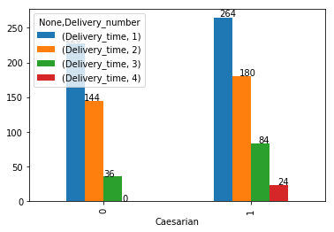

```python
make_pivot ('Caesarian','Delivery_number')#here Caesairan and delivery number is checked
```

| Blood_of_Preassure Caesarian | Delivery_time 0 | Delivery_time 1 | Delivery_time 2 |
| --- | --- | --- | --- |
| 0 | 60 | 276 | 72 |
| 1 | 180 | 204 | 168 |

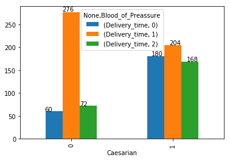

```python
make_pivot ('Caesarian','Blood_of_Preassure')#here the plots for the Caesarian and blood pressure is taken
```

|  | Age | Delivery_number | Delivery_time | Blood_of_Preassure | Heart_Problem | Caesarian |
| --- | --- | --- | --- | --- | --- | --- |
| Age | 1.000000 | 0.427160 | -0.021857 | 0.074448 | 0.250485 | 0.077966 |
| Delivery_number | 0.427160 | 1.000000 | -0.074017 | 0.134315 | 0.200267 | 0.144894 |
| Delivery_time | -0.021857 | -0.074017 | 1.000000 | -0.087298 | -0.003985 | -0.166233 |
| Blood_of_Preassure | 0.074448 | 0.134315 | -0.087298 | 1.000000 | 0.036515 | -0.035760 |
| Heart_Problem | 0.250485 | 0.200267 | -0.003985 | 0.036515 | 1.000000 | 0.352557 |
| Caesarian | 0.077966 | 0.144894 | -0.166233 | -0.035760 | 0.352557 | 1.000000 |

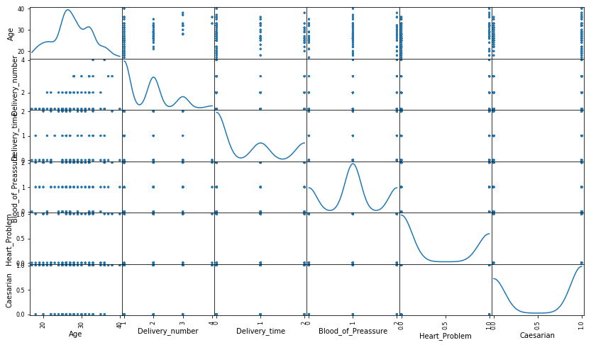

```python
pd.scatter_matrix(df, alpha = 0.3, figsize = (14,8), diagonal = 'kde');
df.corr()# here we are having the correlated values for the above dataset
```

```python
from sklearn.gaussian_process import GaussianProcessClassifier
from sklearn.cross_validation import train_test_split
from sklearn.metrics import accuracy_score
from sklearn.gaussian_process.kernels import RBF
X_train, X_test, y_train, y_test = train_test_split(data,outcome,test_size=0.20,train_size=0.80,random_state=42)
clf =  GaussianProcessClassifier(1.0 * RBF(3.0))
predictions = (clf.fit(X_train, y_train)).predict(X_test)
print(accuracy_score(y_test,predictions))
```

```
0.9322916666666666
```

Oh my god! this classifier gives the accuracy level to 93% because for the reson as the data is clustered to a larger extent we can only see the spots such that it is clustered very extensively.Let us try another classifier if it could be of any best result that this.let us have a trail with the decision tree classifier because it the data is duplicated in the dataset this will train on all the taining data and give the good results>tThe problem with this decison tree classifier is that if the data is unseen in the training set then it may misclassify.|

```python
from sklearn.cross_validation import train_test_split
from sklearn.metrics import f1_score
# TODO: Shuffle and split the data into training and testing subsets
X_train, X_test, y_train, y_test = train_test_split(data,outcome,test_size=0.25,train_size=0.75,random_state=42)
from sklearn.tree import DecisionTreeClassifier
from sklearn.metrics import accuracy_score
reg = DecisionTreeClassifier()#applying the decision tree classifier
reg=reg.fit(X_train,y_train)#fitting the values
y1_test=reg.predict(X_test)#predictiong the values
print(accuracy_score(y1_test,y_test))
print(f1_score(y_test, y1_test, average='macro')  )
```

```
0.925
0.9228571428571428
```

The decison tree classifier gives 92% accuracy which is less than the Gaussian Process classifier this could have happended for the reason due to the large correlated values.Let us use the BeroullliNB classifier because for the reason we had a large content of the binary values so it should work good for us.BernoulliNB is used in the text and image classification for the reason it is good with binary classsification.let us see the results from this model.

```python
from sklearn.naive_bayes import BernoulliNB#here the bernoulli naive bayes is used
X_train, X_test, y_train, y_test = train_test_split(data,outcome,test_size=0.10,train_size=0.90,random_state=42)
bnb = BernoulliNB(binarize=0.0)
bnb.fit(X_train, y_train)
bnb.score(X_test, y_test)
```

```
0.65625
```

we can see that clearly there is a very declination in the accuray scores from the above two models this could have happened for the reason it can only say whether or not a event occurs but cannot count the occurance of the events from the dataset.So that could be the problem for the lowest score.Let us consider the famous boosting algorithum or the basic boosting algorithum adaboostclassifier for the reason in the real life problem it is used for the image classification like human face or background.This could be used in my dataset for the reason we have a large binary data in our dataset

```python
from sklearn.ensemble import AdaBoostClassifier
from sklearn.tree import DecisionTreeClassifier
from sklearn.ensemble import RandomForestClassifier#here the adaboost classifier is used.
X_train, X_test, y_train, y_test = train_test_split(data,outcome,test_size=0.20,train_size=0.80,random_state=42)
clf = AdaBoostClassifier(random_state=42)
predictions = (clf.fit(X_train, y_train)).predict(X_test)
print(accuracy_score(y_test,predictions))
```

```
0.7604166666666666
```

I really thought this could be a good classifer for my data but it has less accuracy to 76% which is more far less than the GaussianProcessClassifier this could have for the reason the model could have overfitted the data.Let us check the support vector machine classifier most of them will not use this because this is best for the large datasests and consumes much time .Let us see what could be the accuracy score.

```python
from sklearn.svm import SVC  #here the support vector classifier is used
svclassifier = SVC(kernel='linear')
predictions=svclassifier.fit(X_train, y_train).predict(X_test)
print(accuracy_score(y_test,predictions))
```

```
0.7239583333333334
```

From the above result we can say that the accuracy_score of the svc is 72% which is not best than the above this could be for the reason SVM returns signed distances to each hyperplane, which is its decision function from mathematical perspective.Now by observing the scatter matrix there is a large amount point which got joined to them so the K-neighbous could be the best algorithum for this kind of datasets

```python
from sklearn.neighbors import KNeighborsClassifier#here the kneighbors classifier is used
X_train, X_test, y_train, y_test = train_test_split(data,outcome,test_size=0.20,train_size=0.80,random_state=42)
clf = KNeighborsClassifier(4)
predictions = (clf.fit(X_train, y_train)).predict(X_test)
print(accuracy_score(y_test,predictions))
```

```
0.953125
```

I think we have attained the maximum accuracy and its time to get the good estimation of parameters by using gridsearchcv before doing this I want to test the latest and most kaggle winning algorithum extreme boosting algorithum the XGBClassifier or extreme gradient boosting classifier.Let us check this out.

```python
from xgboost import XGBClassifier#this cell implements XGBClassifier
from sklearn.metrics import accuracy_score
X_train, X_test, y_train, y_test = train_test_split(data,outcome,test_size=0.20,train_size=0.80,random_state=42)
dpen = []
for i in range(5,11):
    model = XGBClassifier(max_depth = i)
    model.fit(X_train,y_train)#fitting the model
    target = model.predict(X_test)
    dpen.append(accuracy_score(y_test, target))
    print("accuracy : ",i,dpen[i-5])
```

```
accuracy :  5 0.9270833333333334
accuracy :  6 0.9375
accuracy :  7 0.9375
accuracy :  8 0.9375
accuracy :  9 0.9375
accuracy :  10 0.9375
```